# Logical Functions

## Keypoints

1. LF acts upon an expression to return information about the values or sets in the expressions.
2. Most common LF:
   - IF()

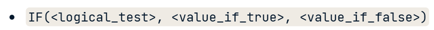

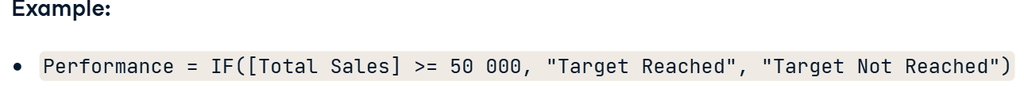

   - AND(), OR() , NOT()

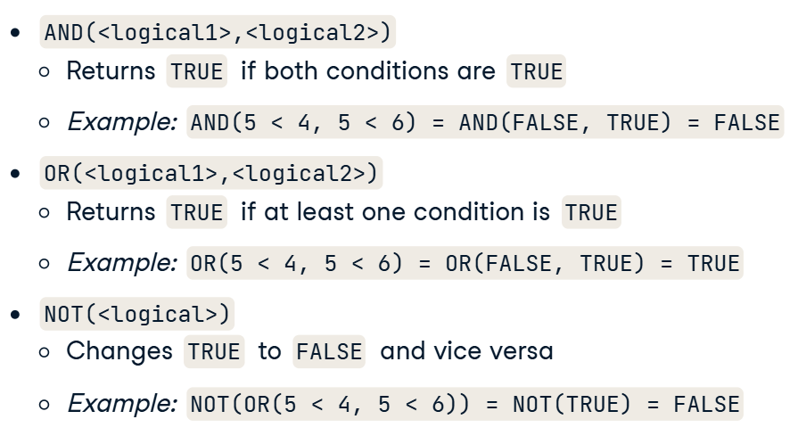

   - SWITCH ()

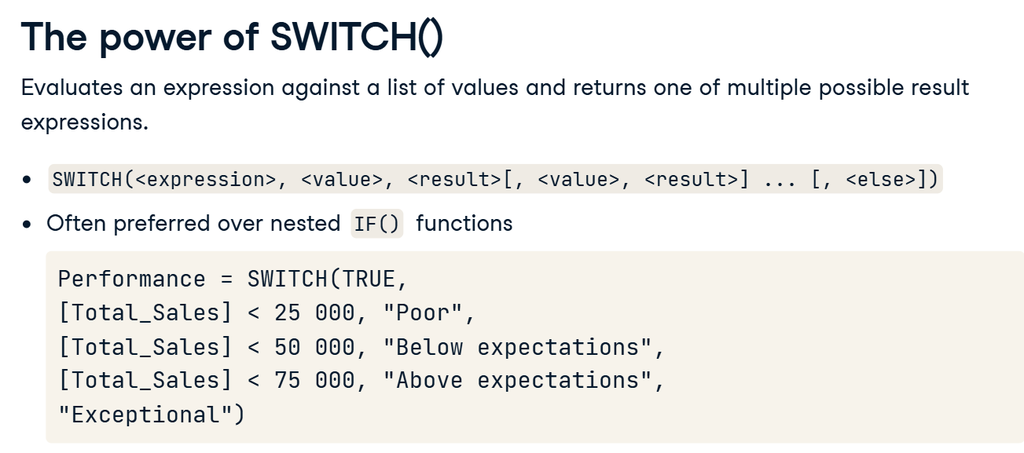

[figure not shown]

## EXERCISE

### IF Function

Totals and subtotals within visualizations can be very important at providing overall characteristics of an attribute (i.e. average, total, etc.).

Unfortunately sometimes, like in the case of our previous RANKX() example in Chapter 2, providing a value in the Total/Subtotal section of table is not useful. For this example you will utilize an IF() statement along with HASONEVALUE() to provide rankings for the employees, in order to remove the value from the totals row.

1. Open 1_1_if.pbix and navigate to the Employee Analysis page. Your job in the next step will be to modify Discount Rate Ranking so that the average ranking does not appear in the total column of the employee table.
2. - Utilize an IF() statement to evaluate if a row of an employee has only one value.
   - If this condition is true, then utilize the RANKX() function previously developed. If false, return a blank.

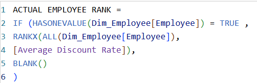

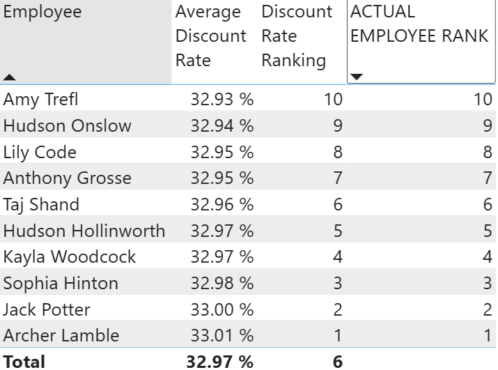

## Exploring SWITCH()

We rarely use a single metric to judge performance in data analysis. We often analyze a few key metrics to better assess performance.

You'll bucket employee performance by discount rate and profit ratio. The cutoff points were defined using an external benchmark analysis.

1. - Navigate to the Employee Analysis page in the Report view.
   - Create a new measure in the _Measures table titled Employee Performance Analysis.

     ```
     Measure Name =
     VAR SomeCalculation = ...
     VAR AnotherPart = ...
     RETURN
     IF(
         <filter situation?>,
         <result>,
         BLANK()
     )
     ```

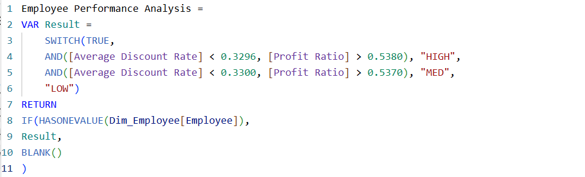

2. Add the new measure to the visualizations on the Employee Analysis page, once to the table on the left, and once to the tooltip of the scatter plot.

[figure not shown]

## Grouping

Similar to buckets, it is sometimes necessary to group sales together. Let's dive deeper into the chiller item analysis. You will be creating **a calculated column to identify high volume/high retail price chiller items**. You will be writing a logic function so **the column will return TRUE or FALSE**, indicating if it was indeed such an item.

1. Create a calculated column High Price/Volume Chiller Item.

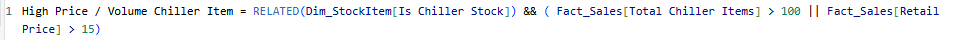

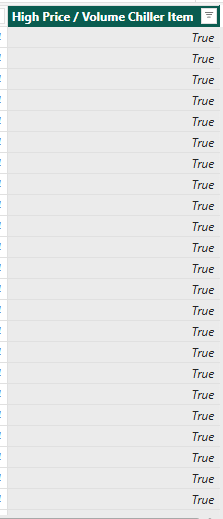

2. Create a new measure Total Sales High Volume/Price Chiller in the _Measures table to calculate the Total Sales of High Price/Volume items.
3. Create a Clustered column chart plotting Total Sales High Volume/Price Chiller by Employee.

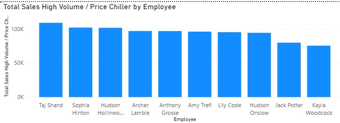

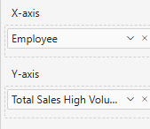